# rJagsNotes

2024-11-18

RJAGS is a gibbs sampler for doing Bayesian statistics in r. This document serves to act as notes and lessons on familiarizing yourself with JAGS and using it as a way to learn Bayesian statistics. ### Table of Contents

### Baby’s first JAG

Now to first understand using JAGS for problem solving, lets examine a sample problem:

- Suppose you have a data set which measures corolla length of Mimulus michiganensis in milimeters and you want to derive an understanding of average petal size and it’s variance.

Begin by loading the necessary packages.

```r
library(rjags)
library(coda)
```

And then move on to creating a data set:

```r
n=250

set.seed(123)
Y<-rnorm(n, 25, 2)
```

In this data set, we have 250 observations of corolla length ($Y$), with an average ($\mu$) length of 25mm and a standard deviation ($\sigma$) of 2mm. We know this simply because we created the data set, but in a real world experiment, $\mu$ and $\sigma$ would be the parameters we are trying to estimate. As such our model for this data would be:

$$Y \sim N(\mu,\sigma)
\tag{1.1}$$

And our prior knowledge might give us an indication about $\mu$ and $\sigma$:

$$\mu \sim N(20,3), \; \sigma\sim gamma(1,1)
\tag{1.2}$$
Here Y is what we observe about the world, and our model states that our observations of the world exist as realizations from a normal distribution.Our prior’s are informed by either observations, existing research on the topic, or just numbers that seem like a reasonable guess.

We can then apply this model to our data using RJAGS:

```r
mod1<-"model{
for (i in 1:n){

Y[i] ~ dnorm(mu,sigma)

}

#priors
mu ~ dnorm(20,3)
sigma ~ dgamma(1,1)
}

"
writeLines(mod1,"mod1.jags.txt")

data<-list("n"=n, "Y"=Y)
inits<-list("mu"=20, "sigma"=3)

jags.m <- jags.model(
  file="mod1.jags.txt",
  data = data,
  inits = inits,
  n.chains = 3,
  n.adapt = 1000
)
```

Here we begin by actually writing out the Jags model, defining that for every value of $Y$, it exists as part of a normal distribution with a mean $\mu$ and deviation $\sigma$. Then using what we know about the world, we can write some estimates, ie. “priors” of what we think those model parameters are like. So here we estimate that the mean $\mu$ is 20, and $\sigma$ is 3.

We then provide the model our data, and some initial starting values to begin working from. And lastly we describe how the model should be used, stating to use 3 MCMC chains, and 1000 adaptations. The next step is to set the sampler to draw from this model we described and to have it estimate our parameters of interest.

```r
params <- c("mu",
            "sigma"
            )

#Sample the distribution some number of times (n.iter)
set.seed(1)

n.iter <- 10000
burn.in <- floor(0.1*n.iter)

samps <- coda.samples(jags.m, params, n.iter=n.iter)
```

And then we can extract the sample plots, and the actual parameter estimates:

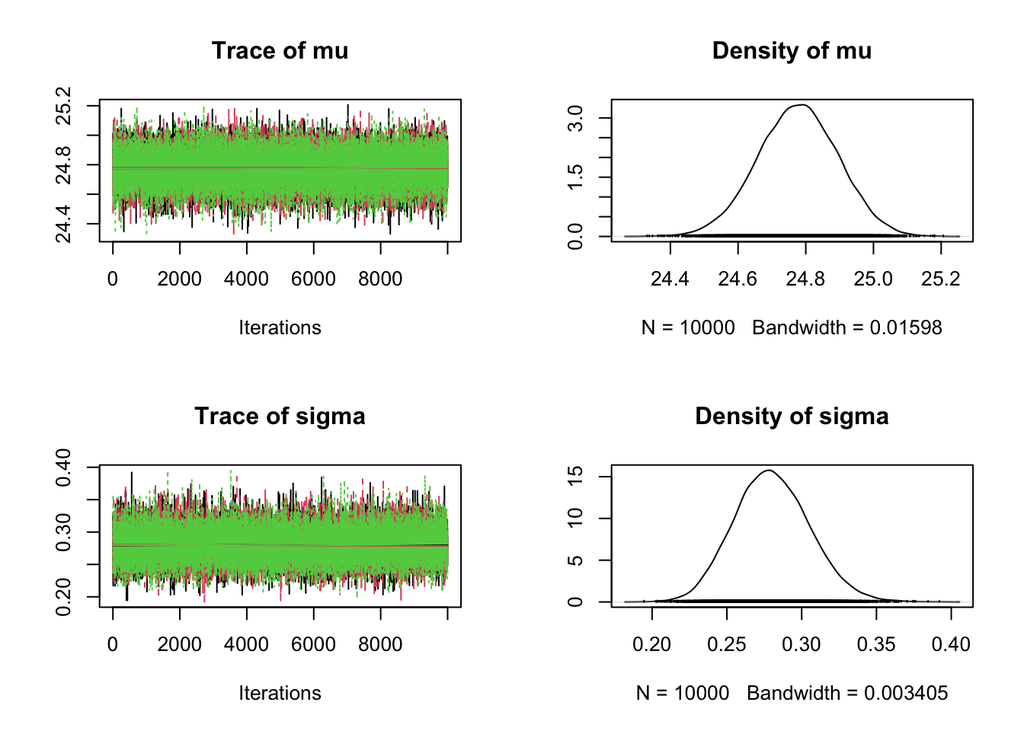

```r
plot(samps)
```

```r
quants<-data.frame(summary(samps)$quantile)
print(quants)
```

```
##            X2.5.       X25.       X50.       X75.     X97.5.
## mu    24.5431715 24.6970940 24.7791027 24.8574633 25.0088083
## sigma  0.2324238  0.2623268  0.2793992  0.2967409  0.3318111
```

Something important about the output plots is that they look both quite flat and quite fuzzy. This demonstrates that the chains both searched quite a bit, and also all converged on some stable estimate of the model parameter. In the cases that these plots are flat and fuzzy, the density plots on the right should look like nice little bell curves. If model convergence is week, we may get bimodal curves or curves with lots of skew. Sometimes you just get poor convergence if you didn’t use enough iterations, so if these plots seem to have a trends which points to convergence in the future, try just bumping these numbers up.

In this case though we got good convergence and the parameter estimates are close enough to what we know the true parameters were that we chose in data simulation.

### T Test

A T test seeks to understand if the differences between two datasets is meaningful or not. That is, given the means of two populations, and a variance for each population, a T test indicates whether or not that difference of means is significant.

- Suppose we have two populations of massasauga rattlesnake (Sistrurus catenatus), and we suspect that there is a difference in the weights of eggs between the two populations. As such, we weigh 150 different eggs from each population and use a difference of means to detect if the difference in weights in meansingfu.

Begin by simulating the data:

```r
x1 <- rpois(150, 11.1)
x2 <- rpois(150, 7.5)

nest.samps<-data.frame(x1,x2)
print(head(nest.samps))
```

```
##   x1 x2
## 1  9  7
## 2 11  5
## 3  8  6
## 4 12  9
## 5 15  7
## 6 13  4
```

In this case we will say that the weights of eggs from population 1 are $X_1$ and the weights of eggs from population two are $X_2$. Our model then is defined as:

$$\begin{align}
X_1 \sim lognormal(\mu_1,\sigma_1),\; X_2 \sim lognormal(\mu_2,
\sigma_2)
\end{align}
\tag{2.1}$$

Here weights are assumed to be any positive number, with a mean $\mu$ and a standard deviation of $\sigma$. And our priors are defined as:

$$\mu_1 \sim N(10,1), \; \mu_2 \sim
N(10,1) \\
\sigma_1 \sim unif(0,10), \; \sigma_2 \sim unif(0,10)
\tag{2.2}$$
And implementing this model in jags:

```r
mod2<-"model{
for (i in 1:n){

X1[i] ~ dlnorm(sigma.1,mu.1)
X2[i] ~ dlnorm(sigma.2,mu.2)
}

#create difference
dif <- mu.1 - mu.2

#priors
mu.1 ~ dnorm(10,1)
mu.2 ~ dnorm(10,1)

sigma.1 ~ dunif(0,10)
sigma.2 ~ dunif(0,10)
}

"
writeLines(mod2,"mod2.jags.txt")

data<-list("n"=nrow(nest.samps), "X1"=nest.samps$x1, "X2"=nest.samps$x2)
inits<-list("mu.1"=10,"mu.2"=10, "sigma.1"=5, "sigma.2"=5)

jags.m <- jags.model(
  file="mod2.jags.txt",
  data = data,
  inits = inits,
  n.chains = 3,
  n.adapt = 1000
)
```

And now we can actually run this model on our data:

```r
params <- c(
            "mu.1",
            "mu.2",
            "sigma.1",
            "sigma.2",
            "dif"
            )
#Sample the distribution some number of times (n.iter)
set.seed(1)

n.iter <- 10000
burn.in <- floor(0.1*n.iter)

samps <- coda.samples(jags.m, params, n.iter=n.iter)
```

And extract the model parameters:

```r
quants<-data.frame(summary(samps)$quantile)
print(quants)
```

```
##            X2.5.     X25.      X50.      X75.    X97.5.
## dif     1.516750 2.789016  3.441487  4.100316  5.334276
## mu.1    8.733002 9.680757 10.184556 10.696428 11.673325
## mu.2    5.581347 6.325774  6.738740  7.154645  8.000580
## sigma.1 2.301531 2.334041  2.351639  2.368685  2.401811
## sigma.2 1.873418 1.914070  1.935101  1.956067  1.996596
```

Importantly whoever, we want to understand are these values of $\mu$ actually different. This is where the $dif$ parameter comes into play. If it were true that $\mu_1$ and $\mu_2$ were the same values, subtracting them would give us a value of 0. If they are different however, they should give us some positive or negative value. The MCMC process used in Bayesian analysis lets us compare for each estimation of $\mu$’s, what their difference is. And as such, when we examine that difference for all realizations of the MCMC simulation after burn in, if the values are different to a significant degree, 0 should not be included in the 95% confidence interval of $dif$. This is of course, exactly what we are seeing when examining the table above. This can be visualized with density plots as well:

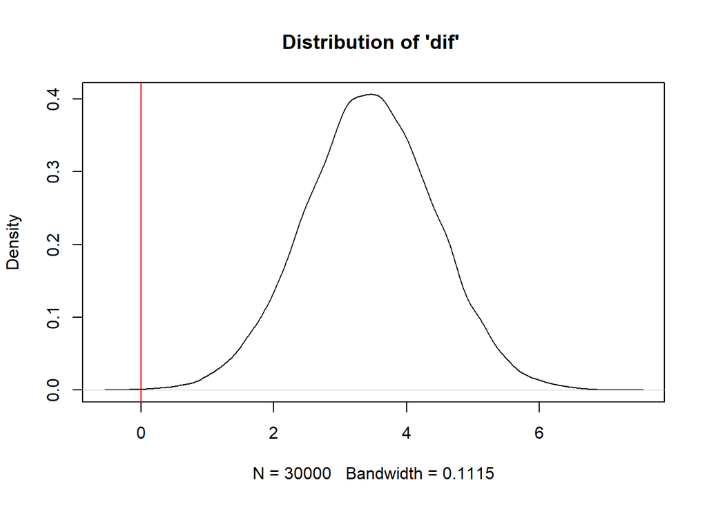

```r
tab<-do.call(rbind.data.frame, samps)
plot(density( tab[[1]]), main = "Distribution of 'dif' ")
abline(v=0,col='red')
```

With the red vertical line being 0, which is of course, not included in the 95% confidence interval under our observed bell curve. Based on this result we can infer that the populations are producing different sized eggs.

### Linear Regression

Linear regression is used to examine the interaction between our observations, and our measured predictors.Consider this example:

- We are interested in understanding how the temperature of streams in the rocky mountains changes as we move up in elevation. As such, we follow a few stream courses up in elevation towards their source, and taking temperatures at random. When we take the temperature, we also record our current elevation.This provides us with our response variable, temperature $Y$, and our predictor, elevation $x$.

We can begin by simulating some data based on this situation:

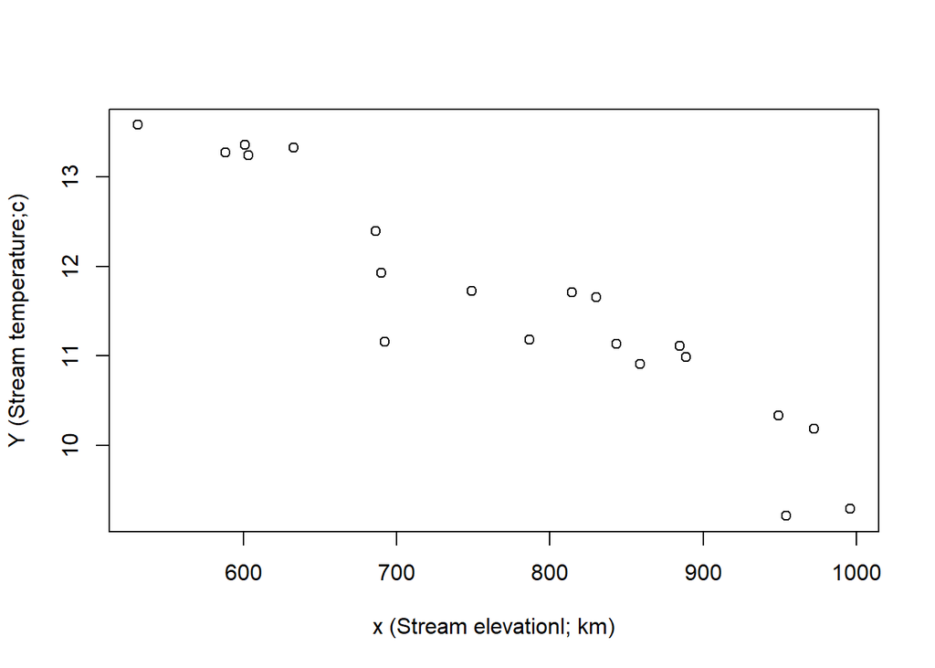

```r
n<-20

x<-runif(n, 500,1000)
Y<-rnorm(n, 17+-(7/1000)*x,.5)

plot(Y~x, xlab="x (Stream elevationl; km)", ylab ="Y (Stream temperature;c)")
```

In this case our model states that our response variable $Y$ is normally distributed with a mean $\mu$ and standard deviation $sigma$:

$$Y \sim N(\mu,\sigma)
\tag{4.1}$$

This should feel pretty familiar at this point. However for this dataset, $x$ is not just some fixed value, instead it is a continuous variable defined by a deterministic relationship:

$$\mu = \beta_0+\beta_1 x +\epsilon
\tag{4.2}$$
And if you look back at our data simulation, we can see that this is precisely how we generated the data for this exercise, by telling the computer that `Y` should be values which have a mean of `17+-(7/1000)*x`. In our model then, we are conserned with identifying those values $\beta_0$ and $\beta_1$ which describe the shape of $x$, as well as what the variability is of values around $x$ as defined by $\sigma$. As such we give the model our prior estimates of $\beta_0$, $\beta_1$, and $\sigma$:

$$\beta_0 \sim N(0,0.001)\\
\beta_1 \sim N(0,0.001)\\
\sigma \sim gamma(1,1)
\tag{4.3}$$

Now implementing this in JAGS:

```r
mod3<-"model{
for (i in 1:n){
Y[i]~dnorm(mu[i],sigma)
mu[i] <- beta.0 + beta.1*x[i]
}

#priors
beta.0 ~ dnorm(0,0.0001)
beta.1 ~ dnorm(0,0.0001)

sigma ~ dgamma(1,1)
}

"
writeLines(mod3,"mod3.jags.txt")

data<-list("n"=n, "x"=x, "Y"=Y)
inits<-list("beta.0"=10,"beta.1"=-0.001, "sigma"=0.1)

jags.m <- jags.model(
  file="mod3.jags.txt",
  data = data,
  inits = inits,
  n.chains = 3,
  n.adapt = 1000
)
```

Now using this model on our data:

```r
params <- c(
            "beta.0",
            "beta.1",
            "sigma"
)

#Sample the distribution some number of times (n.iter)
set.seed(1)

n.iter <- 10000
burn.in <- floor(0.1*n.iter)

samps <- coda.samples(jags.m, params, n.iter=n.iter)
```

Providing us the parameter estimates and confidence intervals:

```r
quants<-data.frame(summary(samps)$quantile)
print(quants)
```

```
##              X2.5.         X25.         X50.         X75.      X97.5.
## beta.0 16.77590030 17.794748288 18.254127250 18.742712144 19.71193859
## beta.1 -0.01043119 -0.009192507 -0.008578954 -0.007999038 -0.00670067
## sigma   1.60015924  2.650753945  3.320346531  4.082831876  5.87946843
```

And then of course we can inspect the chains:

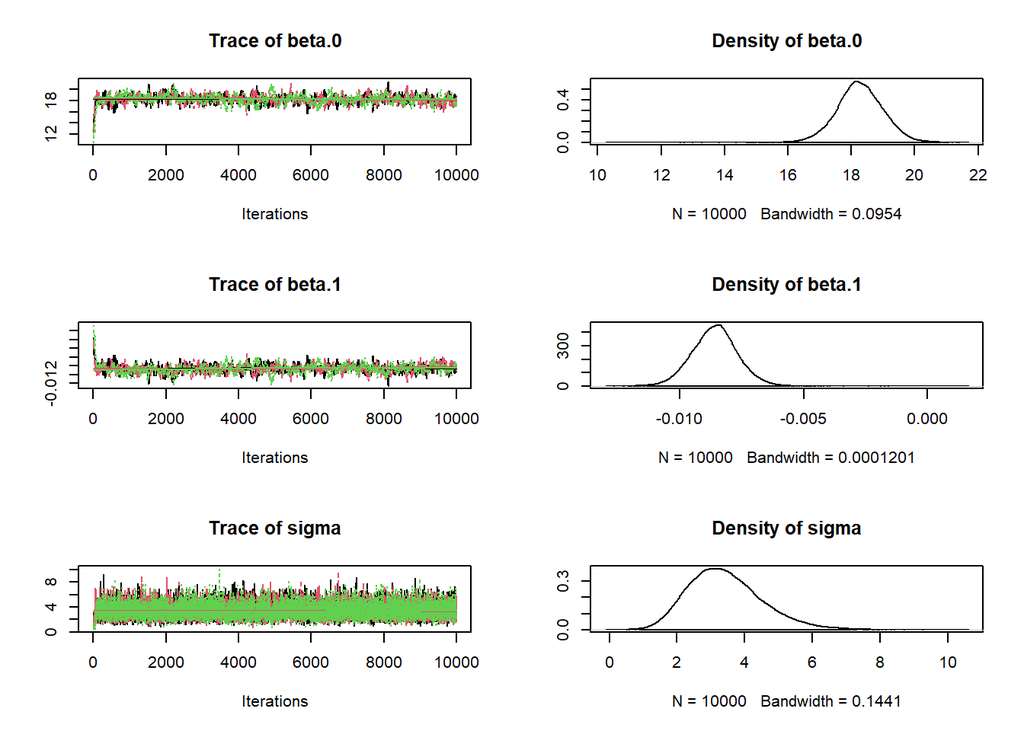

```r
plot(samps)
```

And all is looking good, flat and fuzzy, with the distributions being generally bell shaped and smooth. Additionally, our output parameters seem to make sense, with an estimated stream temperature at an elevation of 0 (ie. the intercept/$\beta_0$) of about 18, and a elevation coefficient (ie. slope/$\beta_1$) which is negative, indicateing the streams getting colder as we move up hill. So now our last step can be to examine our model output using the parameter estimates we generated:

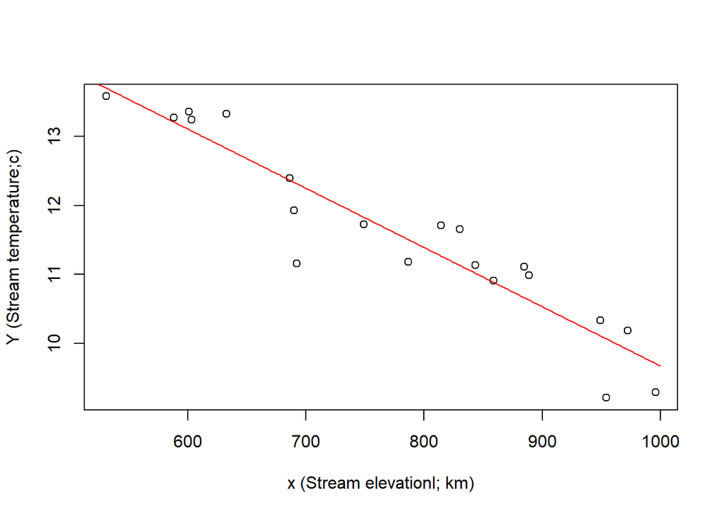

```r
b.0<-quants[1,3]
b.1<-quants[2,3]

plot(Y~x,xlab="x (Stream elevationl; km)", ylab ="Y (Stream temperature;c)")
foobar<-500:1000
lines(b.0+b.1*foobar~foobar,col='red')
```

### Random Effects

Now consider some case where we want to observe a trend, but think that perhaps our experimental design is expressing some influence over the trend we are seeing. Perhaps it is that we think the trend we are seeing changes between different sites. This can be investigated using a random effects model. Lets use this example:

- We are studying how the density of algae growth changes based on the depth of pools in a river system. We go to three separate rivers, visit their pools, measure the depth of the pools, and take some measure of algae concentration.

So we begin by simulating data. In this case, we will simulate the data for each site independently, and then join them all into one larger dataset.

```r
q<-50

x1<-runif(q,1,2)
x2<-runif(q,1.75,3)
x3<-runif(q,2.5,4)

y1<-rnorm(q,2.5+.5*x1,.15)
y2<-rnorm(q,1.6+.6*x2,.15)
y3<-rnorm(q,1+.4*x3,.15)

x<-c(x1,x2,x3)
Y<-c(y1,y2,y3)
groups<-c(rep(1,q),rep(2,q),rep(3,q))

dat<-data.frame(Y,x,groups)
```

We can see here that when we investigate the concentration of algae without taking into account the different rivers, the data appears to have a negative trend (left). Breaking the data up however, it seems that this negative trend may not actually be accurate to the over all process (Right).

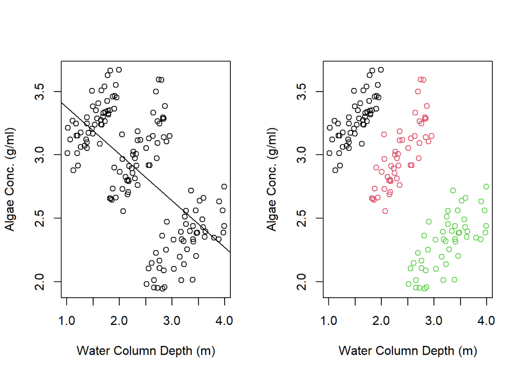

#### Random Intercept Model

Building off the linear model in the previous chapter, we need to not only fit some linear trend line to the data, but also taking into account the random effect that some given site has over the algae growth within the stream. One way to do this would be to let the intercept vary based on which site we were sampling. As such our model will look something like:

$$Y_i \sim N(\mu_{i},\sigma_0)\\
\mu_{i} = \beta_0 +\beta_1X+\gamma_j\\
\\
\gamma_j \sim N(0,\sigma_1)$$
Where $i$ is an index of every observation, and $j$ us an index of each site. This would in turn fit a unique value of $\gamma$ for each site, raising or lowering the intercept for that site.

And prior are then specified as:

$$\beta_1 \sim N(0,0.0001)\\
\beta_2 \sim N(0, 0.0001)$$

```r
mod4<-"model{

  for (i in 1:n){
    Y[i]~dnorm(mu[i],sigma.0)
    mu[i] <- beta.0  +beta.1*x[i] + gamma[group[i]]
  }

for(j in 1:q){
 gamma[j]~dnorm(0,sigma.1)
}


#priors

beta.1 ~ dnorm(0,0.0001)
beta.0 ~ dnorm(0,0.0001)


sigma.0 ~ dgamma(1,1)
sigma.1 ~ dgamma(1,1)
}

"
writeLines(mod4,"mod4.jags.txt")

data<-list("n"=length(Y),"q"=length(unique(groups)),"group"=groups, "x"=x, "Y"=Y)
inits<-list("beta.0"=10,"beta.1"=-0.001, "sigma.0"=0.1, "sigma.1"=0.1)

jags.m <- jags.model(
  file="mod4.jags.txt",
  data = data,
  inits = inits,
  n.chains = 3,
  n.adapt = 1000
)
```

```r
params <- c(
            "beta.0",
            "beta.1",
            "sigma.0",
            "sigma.1",
            "gamma"
)

#Sample the distribution some number of times (n.iter)
set.seed(1)

n.iter <- 10000
burn.in <- floor(0.1*n.iter)

samps <- coda.samples(jags.m, params, n.iter=n.iter)
```

```r
quants<-data.frame(summary(samps)$quantile)
print(quants)
```

```
##                  X2.5.        X25.        X50.        X75.     X97.5.
## beta.0     3.495847532  5.84717592  7.58085981 10.49509901 13.3968497
## beta.1     0.366089376  0.42839339  0.45832726  0.48983678  0.5481430
## gamma[1] -10.825011085 -7.93356050 -5.01460262 -3.26008319 -0.9358885
## gamma[2] -11.497456134 -8.61195568 -5.68234410 -3.92742786 -1.5841768
## gamma[3] -12.604408541 -9.70920634 -6.77722363 -5.02264844 -2.6650571
## sigma.0   21.927717942 25.81987320 27.97184884 30.28125439 34.8906967
## sigma.1    0.004342462  0.01793284  0.03896585  0.09114636  0.4573418
```

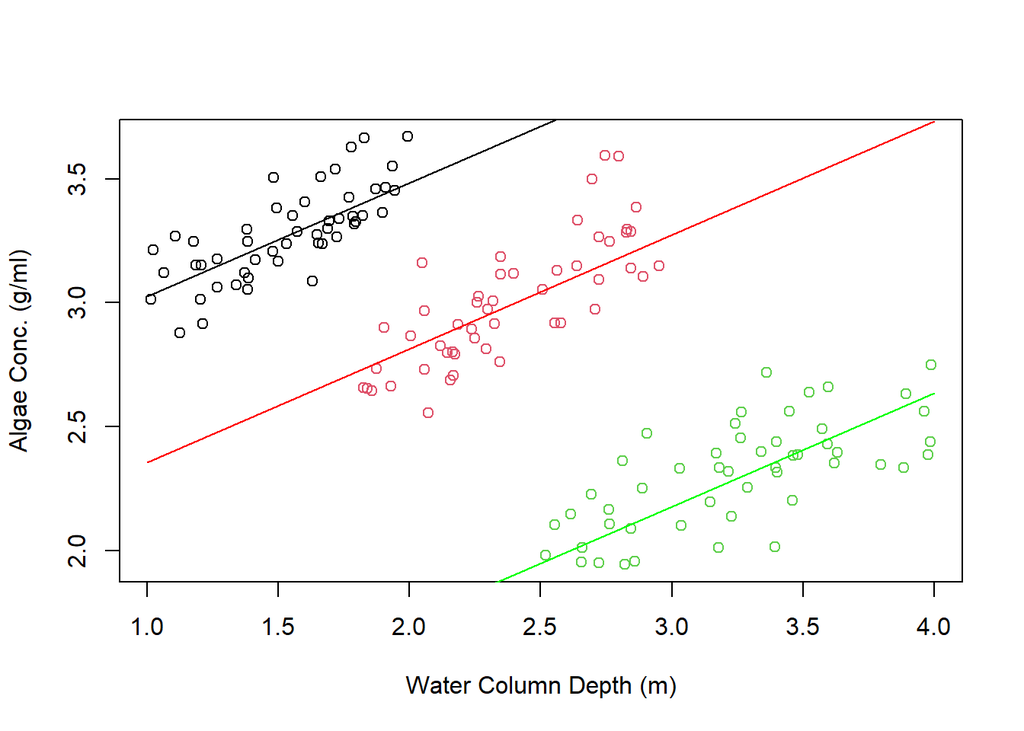

```r
plot(dat$Y~dat$x, col=dat$groups, xlab="Water Column Depth (m)", ylab="Algae Conc. (g/ml)")

foobar<-1:4
lines(quants[1,3]+quants[2,3]*foobar+quants[3,3]~foobar,col="black")
lines(quants[1,3]+quants[2,3]*foobar+quants[4,3]~foobar, col="red")
lines(quants[1,3]+quants[2,3]*foobar+quants[5,3]~foobar, col="green")
```

### References

[Bayesian Statistics, Ed Boone](https://www.youtube.com/watch?v=N4n3CWqGFW4&list=PLjWSgPmViK-MdyGoghJ9xqOH-2yvftsjF)

[Bayesian Hierarchical Models in Ecology, Steve Midway](https://bookdown.org/steve_midway/BHME/)